# 15-영화진흥원 OpenAPI 연동

OpenAPI란, 누구나 사용할 수 있도록 공개된 API로서 대부분의 OpenAPI는 데이터 교환 형식으로 JSON을 사용한다.

> **API** (Application Programming Interface) : 프로그램에서 데이터를 주고 받기 위한 방법

[영화진흥위원회 OpenAPI](http://www.kobis.or.kr/kobisopenapi/)를 활용하면 현재 극장에서 상영중인 영화들에 대한 박스오피스 데이터를 조회할 수 있다.

## #01. 기본 준비 단계

### 1) Key 발급받기

1. 영화진흥위원회 OpenAPI 사이트에 회원가입 후 로그인을 수행한다.
2. **키 발급/관리** 메뉴를 통해 연동에 필요한 인증키 발급받는다.

### 2) 연동 스팩 확인하기

http://www.kobis.or.kr/kobisopenapi/homepg/apiservice/searchServiceInfo.do 페이지를 통해 요청에 필요한 정보와 응답 형식을 확인한다.

### 3) 브라우저를 통한 URL 확인

영화진흥원 OpenAPI 명세서를 통해 요청변수 항목들을 확인하여 전체 URL 구성 후 브라우저를 통해 접근한다.

> http://www.kobis.or.kr/kobisopenapi/webservice/rest/boxoffice/searchDailyBoxOfficeList.json?key=자신의Key값&targetDt=20200110

**targetDt**값의 경우 하루 전 날짜까지 적용 가능하다. 오늘에 해당하는 값을 전달한 경우 아직 집계되지 않은 데이터이므로 데이터가 조회회지 않는다.

웹 브라우저를 통해 JSON을 직접 확인하는 경우 JSON 전문이 한 줄로 표시되어 확인하기 어려운 부분이 있다.

이 경우 크롬 브라우저를 통해 **크롬 웹 스토어**에서 **JSONView** 확장 프로그램 설치하고 재접속 하면 JSON 데이터를 보기 좋게 정렬하고 컬러링을 적용해 준다.

### 4) 필요한 패키지 가져오기

```python
import requests
import json
import datetime as dt
import pandas as pd
from pandas import DataFrame
from matplotlib import pyplot
```

### 5) API 키 준비하기

```python
api_key = "직접설정하세요."
```

### 6) 세션 생성

```python
user_agent = "Mozilla/5.0 (Windows NT 10.0; Win64; x64) AppleWebKit/537.36 (KHTML, like Gecko) Chrome/77.0.3865.120 Safari/537.36"
session = requests.Session()
session.headers.update( {'User-agent': user_agent, 'referer': None} )
```

## #02. 특정 날짜에 대한 박스오피스 관람객 수

영화진흥위원회의 OpenAPI는 오늘을 기준으로 하루 전날 까지의 데이터를 제공한다.

### 1) 접속 주소 준비하기

#### 변수가 치환될 주소 템플릿

```python
url_tpl = "http://www.kobis.or.kr/kobisopenapi/webservice/rest/boxoffice/searchDailyBoxOfficeList.json?key={key}&targetDt={date}"
```

#### 조회날짜 문자열 만들기

여기서는 어제 날짜로 준비함

```python
today = dt.datetime.now()                       # 오늘날짜
delta = dt.timedelta(days = -1)                 # 하루 전을 의미하는 timedelta객체
yesterday = today + delta                       # 오늘 날짜와 timedelta 연산
yesterday_str = yesterday.strftime("%Y%m%d")    # yyyymmdd 형식 문자열로 변환
yesterday_str
```

```
'20210517'
```

#### 최종 접속 주소 확인

```python
api_url = url_tpl.format(key=api_key, date=yesterday_str)
api_url
```

```
'http://www.kobis.or.kr/kobisopenapi/webservice/rest/boxoffice/searchDailyBoxOfficeList.json?key=6d2cf4aa96725383235c717f2e569f1e&targetDt=20210517'
```

### 2) API를 통한 JSON 데이터 가져오기

#### OpenAPI를 통한 JSON 가져오기

```python
r = session.get(api_url)

if r.status_code != 200:
    print("[%d Error] %s" % (r.status_code, r.reason))
    quit()

r.encoding = "utf-8"
r.text
```

```
'{"boxOfficeResult":{"boxofficeType":"일별 박스오피스","showRange":"20210517~20210517","dailyBoxOfficeList":[{"rnum":"1","rank":"1","rankInten":"0","rankOldAndNew":"OLD","movieCd":"20217484","movieNm":"스파이럴","openDt":"2021-05-12","salesAmt":"77722260","salesShare":"24.5","salesInten":"-165815050","salesCha…
```

#### JSON을 딕셔너리로 변환

```python
daily_boxoffice_dict = json.loads(r.text)
daily_boxoffice_dict
```

```
{'boxOfficeResult': {'boxofficeType': '일별 박스오피스',
  'showRange': '20210517~20210517',
  'dailyBoxOfficeList': [{'rnum': '1',
    'rank': '1',
    'rankInten': '0',
    'rankOldAndNew': 'OLD',
    'movieCd': '20217484',
    'movieNm': '스파이럴',
    'openDt': '2021-05-12',
    'salesAmt': '77722260',
    'salesShare': '24.5',
    'salesInten': '-165815050',
    'salesChange': '-68.1',
    'salesAcc': '961101820',
    'audiCnt': '8026',
    'audiInten': '-15562',
    'audiChange': '-66',
    'audiAcc': '96334',
    'scrnCnt': '616',
    'showCnt': '1914'},
   {'rnum': '2',
    'rank': '2',
    'rankInten': '2',
    'rankOldAndNew': 'OLD',
    'movieCd': '20200703',
    'movieNm': '극장판 귀멸의 칼날: 무한열차편',
    'openDt': '2021-01-27',
    'salesAmt': '34347410',
    'salesShare': '10.8',
    'salesInten': '-81424310',
    'salesChange': '-70.3',
    'salesAcc': '19337985640',
    'audiCnt': '3579',
    'audiInten': '-8218',
    'audiChange': '-69.7',
    'audiAcc': '2007785',
    'scrnCnt': '426',
    'showCnt': '674'},
   {'rnum': '3',
    'rank': '3',
```

[output cut: 127 more lines]

```
    'rankOldAndNew': 'OLD',
    'movieCd': '20216710',
    'movieNm': '명탐정 코난: 비색의 탄환',
    'openDt': '2021-04-16',
    'salesAmt': '6661370',
    'salesShare': '2.1',
    'salesInten': '-28566120',
    'salesChange': '-81.1',
    'salesAcc': '2096232480',
    'audiCnt': '725',
    'audiInten': '-2962',
    'audiChange': '-80.3',
    'audiAcc': '222419',
    'scrnCnt': '165',
    'showCnt': '201'}]}}
```

#### 딕셔너리를 데이터프레임으로 변환

```python
daily_boxoffice_df = DataFrame(daily_boxoffice_dict['boxOfficeResult']['dailyBoxOfficeList'])
daily_boxoffice_df
```

|  | rnum | rank | rankInten | rankOldAndNew | movieCd | movieNm | openDt | salesAmt | salesShare | salesInten | salesChange | salesAcc | audiCnt | audiInten | audiChange | audiAcc | scrnCnt | showCnt |
| --- | --- | --- | --- | --- | --- | --- | --- | --- | --- | --- | --- | --- | --- | --- | --- | --- | --- | --- |
| 0 | 1 | 1 | 0 | OLD | 20217484 | 스파이럴 | 2021-05-12 | 77722260 | 24.5 | -165815050 | -68.1 | 961101820 | 8026 | -15562 | -66 | 96334 | 616 | 1914 |
| 1 | 2 | 2 | 2 | OLD | 20200703 | 극장판 귀멸의 칼날: 무한열차편 | 2021-01-27 | 34347410 | 10.8 | -81424310 | -70.3 | 19337985640 | 3579 | -8218 | -69.7 | 2007785 | 426 | 674 |
| 2 | 3 | 3 | 0 | OLD | 20216703 | 더 스파이 | 2021-04-28 | 32397750 | 10.2 | -111132240 | -77.4 | 2648889720 | 3553 | -11128 | -75.8 | 286639 | 464 | 910 |
| 3 | 4 | 4 | 1 | OLD | 20193068 | 비와 당신의 이야기 | 2021-04-28 | 28524430 | 9.0 | -74970210 | -72.4 | 3229902860 | 3140 | -7407 | -70.2 | 350031 | 474 | 906 |
| 4 | 5 | 5 | 2 | OLD | 20205144 | 미나리 | 2021-03-03 | 17165620 | 5.4 | -42035080 | -71 | 10065419760 | 2021 | -4193 | -67.5 | 1115831 | 354 | 475 |
| 5 | 6 | 6 | 0 | OLD | 20194501 | 내일의 기억 | 2021-04-21 | 16787190 | 5.3 | -50723570 | -75.1 | 2953310230 | 1765 | -4820 | -73.2 | 325591 | 293 | 458 |
| 6 | 7 | 7 | 2 | OLD | 20214763 | 내겐 너무 소중한 너 | 2021-05-12 | 13198050 | 4.2 | -26919660 | -67.1 | 173196420 | 1473 | -2752 | -65.1 | 18831 | 333 | 535 |
| 7 | 8 | 8 | 3 | OLD | 20200524 | 아들의 이름으로 | 2021-05-12 | 11031900 | 3.5 | -18862130 | -63.1 | 143593490 | 1311 | -1944 | -59.7 | 16509 | 326 | 502 |
| 8 | 9 | 9 | -7 | OLD | 20202585 | 크루즈 패밀리: 뉴 에이지 | 2021-05-05 | 10664230 | 3.4 | -134869810 | -92.7 | 1838716900 | 1190 | -15116 | -92.7 | 207874 | 280 | 401 |
| 9 | 10 | 10 | 0 | OLD | 20216710 | 명탐정 코난: 비색의 탄환 | 2021-04-16 | 6661370 | 2.1 | -28566120 | -81.1 | 2096232480 | 725 | -2962 | -80.3 | 222419 | 165 | 201 |

### 2) 데이터 전처리

#### 사용할 컬럼만 추출

```python
tmp_df = daily_boxoffice_df.filter(['movieNm', 'audiCnt'])
tmp_df
```

|  | movieNm | audiCnt |
| --- | --- | --- |
| 0 | 스파이럴 | 8026 |
| 1 | 극장판 귀멸의 칼날: 무한열차편 | 3579 |
| 2 | 더 스파이 | 3553 |
| 3 | 비와 당신의 이야기 | 3140 |
| 4 | 미나리 | 2021 |
| 5 | 내일의 기억 | 1765 |
| 6 | 내겐 너무 소중한 너 | 1473 |
| 7 | 아들의 이름으로 | 1311 |
| 8 | 크루즈 패밀리: 뉴 에이지 | 1190 |
| 9 | 명탐정 코난: 비색의 탄환 | 725 |

#### 컬럼이름 변경

```python
tmp_df2 = tmp_df.rename(columns={'movieNm': '영화제목', 'audiCnt': '관람객'})
tmp_df2
```

|  | 영화제목 | 관람객 |
| --- | --- | --- |
| 0 | 스파이럴 | 8026 |
| 1 | 극장판 귀멸의 칼날: 무한열차편 | 3579 |
| 2 | 더 스파이 | 3553 |
| 3 | 비와 당신의 이야기 | 3140 |
| 4 | 미나리 | 2021 |
| 5 | 내일의 기억 | 1765 |
| 6 | 내겐 너무 소중한 너 | 1473 |
| 7 | 아들의 이름으로 | 1311 |
| 8 | 크루즈 패밀리: 뉴 에이지 | 1190 |
| 9 | 명탐정 코난: 비색의 탄환 | 725 |

#### 영화제목을 인덱스로 지정

```python
daily_rank_df = tmp_df2.set_index('영화제목')
daily_rank_df
```

| 영화제목 | 관람객 |
| --- | --- |
| 스파이럴 | 8026 |
| 극장판 귀멸의 칼날: 무한열차편 | 3579 |
| 더 스파이 | 3553 |
| 비와 당신의 이야기 | 3140 |
| 미나리 | 2021 |
| 내일의 기억 | 1765 |
| 내겐 너무 소중한 너 | 1473 |
| 아들의 이름으로 | 1311 |
| 크루즈 패밀리: 뉴 에이지 | 1190 |
| 명탐정 코난: 비색의 탄환 | 725 |

#### 관람객 컬럼에 대한 데이터 타입 확인

외부에서 수집한 데이터의 경우 숫자 모양을 한 문자열 형식인 경우가 대부분이기 때문에 반드시 분석할 컬럼만 출력하여 type을 확인해야 한다.

type이 `int`, 나 `float` 형식이 아닌 경우 타입 변환 처리가 필수적으로 요구된다.

```python
daily_rank_df['관람객']
```

```
영화제목
스파이럴                 8026
극장판 귀멸의 칼날: 무한열차편    3579
더 스파이                3553
비와 당신의 이야기           3140
미나리                  2021
내일의 기억               1765
내겐 너무 소중한 너          1473
아들의 이름으로             1311
크루즈 패밀리: 뉴 에이지       1190
명탐정 코난: 비색의 탄환        725
Name: 관람객, dtype: object
```

#### 관람객 컬럼의 타입을 숫자형식으로 변환

```python
daily_rank_df['관람객'] = daily_rank_df['관람객'].apply(pd.to_numeric)
daily_rank_df['관람객']
```

```
영화제목
스파이럴                 8026
극장판 귀멸의 칼날: 무한열차편    3579
더 스파이                3553
비와 당신의 이야기           3140
미나리                  2021
내일의 기억               1765
내겐 너무 소중한 너          1473
아들의 이름으로             1311
크루즈 패밀리: 뉴 에이지       1190
명탐정 코난: 비색의 탄환        725
Name: 관람객, dtype: int64
```

### 3) 데이터 시각화

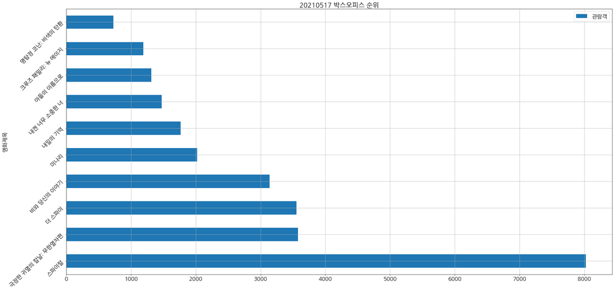

```python
# 그래프 만들기
pyplot.rcParams["font.family"] = 'NanumGothic'
pyplot.rcParams["font.size"] = 18
pyplot.rcParams["figure.figsize"] = (32, 16)

# 전체 컬럼에 대한 시각화
daily_rank_df.plot.barh(rot=45)
pyplot.grid()
pyplot.title("%s 박스오피스 순위" % yesterday_str)
pyplot.legend()
pyplot.show()
pyplot.close()
```

## #03. 영화별 1주일 간의 관람객 수 변동 현황

URL에 접속하는 연동 부분을 하나의 블록으로 묶고 날짜를 변경해 가며 1주일간의 변화량 확인한다.

### 1) 반복문을 수행하며 1주일치 데이터 수집하기

```python
# 반복을 수행하면서 생성되는 데이터프레임을 누적시킬 빈 데이터 프레임 준비
영화관람객수_df = DataFrame()

# 일주일간의 기간을 위한 반복문 구성
for i in range(-7, 0):

    #### 조회날짜 문자열 만들기
    today = dt.datetime.now()                       # 오늘날짜
    delta = dt.timedelta(days = i)                  # i일 전을 의미하는 timedelta객체
    yesterday = today + delta                       # 오늘 날짜와 timedelta 연산
    yesterday_str = yesterday.strftime("%Y%m%d")    # yyyymmdd 형식 문자열로 변환
    #print(yesterday_str)

    #### 최종 접속 주소 확인
    api_url = url_tpl.format(key=api_key, date=yesterday_str)
    #print(api_url)

    #### API를 통한 JSON 데이터 가져오기
    r = session.get(api_url)

    if r.status_code != 200:
        print("[%d Error] %s" % (r.status_code, r.reason))
        # 특정 주소에 대해 에러가 발생하더라도 다른 주소에 대한 수집을 시도하기 위해 반복을 계속 수행
        continue

    r.encoding = "utf-8"
    #print(r.text)
    #print("-" * 50)

    #### 데이터 프레임으로 변환
    daily_boxoffice_dict = json.loads(r.text)
    daily_boxoffice_df = DataFrame(daily_boxoffice_dict['boxOfficeResult']['dailyBoxOfficeList'])
    #print(daily_boxoffice_df)

    #### 사용할 컬럼만 추출
    tmp_df = daily_boxoffice_df.filter(['movieNm', 'audiCnt'])
    #print(tmp_df)

    #### 컬럼이름 변경 --> 관람객 수를 의미하는 컬럼을 해당 날짜로 변경한다.
    tmp_df2 = tmp_df.rename(columns={'movieNm': '영화제목', 'audiCnt': yesterday_str})

    #### 영화제목을 인덱스로 지정
    daily_rank_df = tmp_df2.set_index('영화제목')

    #### 관람객 컬럼의 타입을 숫자형식으로 변환
    daily_rank_df[yesterday_str] = daily_rank_df[yesterday_str].apply(pd.to_numeric)

    #### 영화이름(daily_rank_df의 인덱스)가 동일한 데이터를 기준으로 누적
    #### -> how값을 outer로 지정하여 중복되지 않는 인덱스명(영화제목)도 누락되지 않도록 한다.
    영화관람객수_df = pd.merge(영화관람객수_df, daily_rank_df, left_index=True, right_index=True, how="outer")

############ 최종 결과 출력
영화관람객수_df
```

| 영화제목 | 20210511 | 20210512 | 20210513 | 20210514 | 20210515 | 20210516 | 20210517 |
| --- | --- | --- | --- | --- | --- | --- | --- |
| 극장판 귀멸의 칼날: 무한열차편 | 3864.0 | 3601.0 | 3475.0 | 4976.0 | 12354.0 | 11797.0 | 3579.0 |
| 극장판 콩순이: 장난감나라 대모험 | 1449.0 | NaN | NaN | NaN | 5042.0 | 5356.0 | NaN |
| 내가 죽기를 바라는 자들 | 2335.0 | NaN | NaN | NaN | NaN | NaN | NaN |
| 내겐 너무 소중한 너 | NaN | NaN | 1599.0 | 1874.0 | 4288.0 | 4225.0 | 1473.0 |
| 내일의 기억 | 2632.0 | 1793.0 | 1648.0 | 2499.0 | 6597.0 | 6585.0 | 1765.0 |
| 더 스파이 | 5254.0 | 3269.0 | 3278.0 | 5627.0 | 16580.0 | 14681.0 | 3553.0 |
| 명탐정 코난: 비색의 탄환 | 1052.0 | NaN | NaN | 1187.0 | 3846.0 | 3687.0 | 725.0 |
| 미나리 | 2954.0 | 2347.0 | 2082.0 | 2425.0 | 6039.0 | 6214.0 | 2021.0 |
| 비와 당신의 이야기 | 5927.0 | 4449.0 | 3963.0 | 5073.0 | 12152.0 | 10547.0 | 3140.0 |
| 빅 피쉬 | NaN | 1849.0 | NaN | NaN | NaN | NaN | NaN |
| 슈퍼노바 | NaN | 2211.0 | 1355.0 | NaN | NaN | NaN | NaN |
| 스파이럴 | 2085.0 | 15841.0 | 9526.0 | 10448.0 | 26547.0 | 23588.0 | 8026.0 |
| 아들의 이름으로 | NaN | 2479.0 | 2155.0 | 2370.0 | NaN | NaN | 1311.0 |
| 크루즈 패밀리: 뉴 에이지 | 2707.0 | 1923.0 | 1374.0 | 2061.0 | 15001.0 | 16306.0 | 1190.0 |

### 2) 데이터 정제

#### 결측치 대체

관람객 수가 결측치인 경우는 병합 과정에서 해당 날짜에 개봉하지 않은 영화를 의미한다.

결측치인 경우 관람객 수가 0이라는 의미이므로 결측치 대체법을 적용한다.

```python
final_df = 영화관람객수_df.fillna(0)
final_df
```

| 영화제목 | 20210511 | 20210512 | 20210513 | 20210514 | 20210515 | 20210516 | 20210517 |
| --- | --- | --- | --- | --- | --- | --- | --- |
| 극장판 귀멸의 칼날: 무한열차편 | 3864.0 | 3601.0 | 3475.0 | 4976.0 | 12354.0 | 11797.0 | 3579.0 |
| 극장판 콩순이: 장난감나라 대모험 | 1449.0 | 0.0 | 0.0 | 0.0 | 5042.0 | 5356.0 | 0.0 |
| 내가 죽기를 바라는 자들 | 2335.0 | 0.0 | 0.0 | 0.0 | 0.0 | 0.0 | 0.0 |
| 내겐 너무 소중한 너 | 0.0 | 0.0 | 1599.0 | 1874.0 | 4288.0 | 4225.0 | 1473.0 |
| 내일의 기억 | 2632.0 | 1793.0 | 1648.0 | 2499.0 | 6597.0 | 6585.0 | 1765.0 |
| 더 스파이 | 5254.0 | 3269.0 | 3278.0 | 5627.0 | 16580.0 | 14681.0 | 3553.0 |
| 명탐정 코난: 비색의 탄환 | 1052.0 | 0.0 | 0.0 | 1187.0 | 3846.0 | 3687.0 | 725.0 |
| 미나리 | 2954.0 | 2347.0 | 2082.0 | 2425.0 | 6039.0 | 6214.0 | 2021.0 |
| 비와 당신의 이야기 | 5927.0 | 4449.0 | 3963.0 | 5073.0 | 12152.0 | 10547.0 | 3140.0 |
| 빅 피쉬 | 0.0 | 1849.0 | 0.0 | 0.0 | 0.0 | 0.0 | 0.0 |
| 슈퍼노바 | 0.0 | 2211.0 | 1355.0 | 0.0 | 0.0 | 0.0 | 0.0 |
| 스파이럴 | 2085.0 | 15841.0 | 9526.0 | 10448.0 | 26547.0 | 23588.0 | 8026.0 |
| 아들의 이름으로 | 0.0 | 2479.0 | 2155.0 | 2370.0 | 0.0 | 0.0 | 1311.0 |
| 크루즈 패밀리: 뉴 에이지 | 2707.0 | 1923.0 | 1374.0 | 2061.0 | 15001.0 | 16306.0 | 1190.0 |

### 3) 데이터 시각화

시간에 따른 데이터의 변화를 표현하기 적합한 형태는 **선 그래프(=시계열 그래프)** 이다.

데이터 프래임을 선 그래프로 표현할 경우 각각의 컬럼이 선으로 표현되고 인덱스가 x축, 값이 y축으로 사용된다.

> 현재 DataFrame을 바로 시각화 할 경우 영화 제목이 x축이 되고 날짜별로 하나의 선이 구현되어 맞지 않는 그래프가 표현된다.

각각의 영화가 하나의 선이 되고, 날짜가 x축, 관람객 수가 y축이 되도록 하려면 현재 데이터 프래임의 컬럼과 인덱스를 맞바꾼 형태인 전치를 통해 그래프를 표현해야 한다.

#### 데이터프레임의 전치 확인

```python
전치데이터 = final_df.T
전치데이터
```

| 영화제목 | 극장판 귀멸의 칼날: 무한열차편 | 극장판 콩순이: 장난감나라 대모험 | 내가 죽기를 바라는 자들 | 내겐 너무 소중한 너 | 내일의 기억 | 더 스파이 | 명탐정 코난: 비색의 탄환 | 미나리 | 비와 당신의 이야기 | 빅 피쉬 | 슈퍼노바 | 스파이럴 | 아들의 이름으로 | 크루즈 패밀리: 뉴 에이지 |
| --- | --- | --- | --- | --- | --- | --- | --- | --- | --- | --- | --- | --- | --- | --- |
| 20210511 | 3864.0 | 1449.0 | 2335.0 | 0.0 | 2632.0 | 5254.0 | 1052.0 | 2954.0 | 5927.0 | 0.0 | 0.0 | 2085.0 | 0.0 | 2707.0 |
| 20210512 | 3601.0 | 0.0 | 0.0 | 0.0 | 1793.0 | 3269.0 | 0.0 | 2347.0 | 4449.0 | 1849.0 | 2211.0 | 15841.0 | 2479.0 | 1923.0 |
| 20210513 | 3475.0 | 0.0 | 0.0 | 1599.0 | 1648.0 | 3278.0 | 0.0 | 2082.0 | 3963.0 | 0.0 | 1355.0 | 9526.0 | 2155.0 | 1374.0 |
| 20210514 | 4976.0 | 0.0 | 0.0 | 1874.0 | 2499.0 | 5627.0 | 1187.0 | 2425.0 | 5073.0 | 0.0 | 0.0 | 10448.0 | 2370.0 | 2061.0 |
| 20210515 | 12354.0 | 5042.0 | 0.0 | 4288.0 | 6597.0 | 16580.0 | 3846.0 | 6039.0 | 12152.0 | 0.0 | 0.0 | 26547.0 | 0.0 | 15001.0 |
| 20210516 | 11797.0 | 5356.0 | 0.0 | 4225.0 | 6585.0 | 14681.0 | 3687.0 | 6214.0 | 10547.0 | 0.0 | 0.0 | 23588.0 | 0.0 | 16306.0 |
| 20210517 | 3579.0 | 0.0 | 0.0 | 1473.0 | 1765.0 | 3553.0 | 725.0 | 2021.0 | 3140.0 | 0.0 | 0.0 | 8026.0 | 1311.0 | 1190.0 |

#### 전치를 사용한 그래프

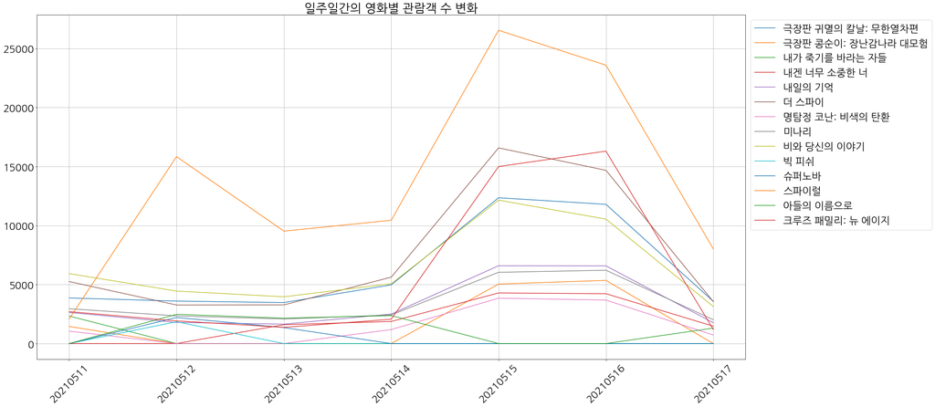

```python
pyplot.rcParams["font.family"] = 'NanumGothic'
pyplot.rcParams["font.size"] = 24
pyplot.rcParams["figure.figsize"] = (30, 15)

전치데이터.plot(rot=45)
pyplot.grid()
pyplot.title("일주일간의 영화별 관람객 수 변화")
pyplot.legend(bbox_to_anchor=(1, 1))
pyplot.show()
pyplot.close()
```